# Exercise 1.1: Multiple Regression SOLUTION

## Violent Crime Rates by US State

The data set `USArrests` contains statistics, in arrests per 100,000 residents for assault, murder, and rape in each of the 50 US states in 1973. Also given is the percent of the population living in urban areas.

Research question: *Which variables predict murder rates and to what degree?*

### Design

The data comes with `R`, so we can load it right away. But at first, we load the `tidyverse` package, because these are the functions we want to use throughout this exercise.

```r
library("tidyverse")
theme_set(theme_bw(base_size = 17))
data(USArrests)
str(USArrests)
```

```
'data.frame':   50 obs. of  4 variables:
 $ Murder  : num  13.2 10 8.1 8.8 9 7.9 3.3 5.9 15.4 17.4 ...
 $ Assault : int  236 263 294 190 276 204 110 238 335 211 ...
 $ UrbanPop: int  58 48 80 50 91 78 77 72 80 60 ...
 $ Rape    : num  21.2 44.5 31 19.5 40.6 38.7 11.1 15.8 31.9 25.8 ...
```

The `data.frame` has 50 observations (one for each state) on 4 variables. The columns in the data are:

- `Murder`: Murder arrests (per 100,000)
- `Assault`: Assault arrests (per 100,000)
- `UrbanPop`: Percent urban population
- `Rape`: Rape arrests (per 100,000)

Several of the variables show correlations among each other.

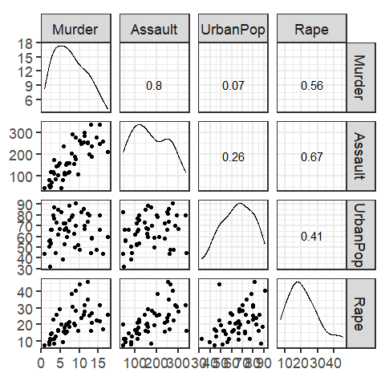

```r
GGally::ggscatmat(USArrests)
```

When looking at the zero-order correlation displayed in the upper-triangle of the pairs plot, we see that both, `Assault` and `Rape` appear to predict murder rates.

## Task 1: Simple Linear Models

Create one simple linear regression model with murder rate as dependent variable and each of the other variables as independent variable.

Which of the three variables shows a significant effect on murder rates?

### Solution

```r
ma <- lm(Murder ~ Assault, USArrests)
summary(ma)
```

```
Call:
lm(formula = Murder ~ Assault, data = USArrests)

Residuals:
    Min      1Q  Median      3Q     Max
-4.8528 -1.7456 -0.3979  1.3044  7.9256

Coefficients:
            Estimate Std. Error t value Pr(>|t|)
(Intercept) 0.631683   0.854776   0.739    0.464
Assault     0.041909   0.004507   9.298  2.6e-12 ***
---
Signif. codes:  0 ‘***’ 0.001 ‘**’ 0.01 ‘*’ 0.05 ‘.’ 0.1 ‘ ’ 1

Residual standard error: 2.629 on 48 degrees of freedom
Multiple R-squared:  0.643, Adjusted R-squared:  0.6356
F-statistic: 86.45 on 1 and 48 DF,  p-value: 2.596e-12
```

```r
mu <- lm(Murder ~ UrbanPop, USArrests)
summary(mu)
```

```
Call:
lm(formula = Murder ~ UrbanPop, data = USArrests)

Residuals:
   Min     1Q Median     3Q    Max
-6.537 -3.736 -0.779  3.332  9.728

Coefficients:
            Estimate Std. Error t value Pr(>|t|)
(Intercept)  6.41594    2.90669   2.207   0.0321 *
UrbanPop     0.02093    0.04333   0.483   0.6312
---
Signif. codes:  0 ‘***’ 0.001 ‘**’ 0.01 ‘*’ 0.05 ‘.’ 0.1 ‘ ’ 1

Residual standard error: 4.39 on 48 degrees of freedom
Multiple R-squared:  0.00484,   Adjusted R-squared:  -0.01589
F-statistic: 0.2335 on 1 and 48 DF,  p-value: 0.6312
```

```r
mr <- lm(Murder ~ Rape, USArrests)
summary(mr)
```

```
Call:
lm(formula = Murder ~ Rape, data = USArrests)

Residuals:
    Min      1Q  Median      3Q     Max
-5.0900 -2.4025 -0.5731  1.7095  9.3949

Coefficients:
            Estimate Std. Error t value Pr(>|t|)
(Intercept)  2.22367    1.28456   1.731   0.0899 .
Rape         0.26207    0.05544   4.727 2.03e-05 ***
---
Signif. codes:  0 ‘***’ 0.001 ‘**’ 0.01 ‘*’ 0.05 ‘.’ 0.1 ‘ ’ 1

Residual standard error: 3.635 on 48 degrees of freedom
Multiple R-squared:  0.3176,    Adjusted R-squared:  0.3034
F-statistic: 22.34 on 1 and 48 DF,  p-value: 2.031e-05
```

As expected from the pairs plot, assault and rape rates are significant predictors for murder rates, but not the percentage of urban population. The latter effect is positive, but small.

## Task 2: Multiple Regression

Create one overall model with murder rate as dependent variable and the three other variables as independent variables (without interactions).

Which of the three variables now shows a significant effect on murder rates? If there are differences, how can these differences be explained?

### Solution

```r
mall <- lm(Murder ~ Assault + UrbanPop + Rape, data = USArrests)
summary(mall)
```

```
Call:
lm(formula = Murder ~ Assault + UrbanPop + Rape, data = USArrests)

Residuals:
    Min      1Q  Median      3Q     Max
-4.3990 -1.9127 -0.3444  1.2557  7.4279

Coefficients:
             Estimate Std. Error t value Pr(>|t|)
(Intercept)  3.276639   1.737997   1.885   0.0657 .
Assault      0.039777   0.005912   6.729 2.33e-08 ***
UrbanPop    -0.054694   0.027880  -1.962   0.0559 .
Rape         0.061399   0.055740   1.102   0.2764
---
Signif. codes:  0 ‘***’ 0.001 ‘**’ 0.01 ‘*’ 0.05 ‘.’ 0.1 ‘ ’ 1

Residual standard error: 2.574 on 46 degrees of freedom
Multiple R-squared:  0.6721,    Adjusted R-squared:  0.6507
F-statistic: 31.42 on 3 and 46 DF,  p-value: 3.322e-11
```

When adding all three variables to a model, only assault rates are a significant predictor for murder rates. Rape is now clearly non-significant.

We can see how this happens when reproducing both values via the residuals. We begin with the assault rates.

The zero-order effect is similar to the final effect.

```r
summary(ma)$coefficients %>% zapsmall
```

```
            Estimate Std. Error  t value Pr(>|t|)
(Intercept) 0.631683   0.854776 0.739004 0.463503
Assault     0.041909   0.004507 9.298069 0.000000
```

We can then predict the assault rates from the other two IVs. If we use the resulting residuals as a predictor for murder rates we recreate the value from the final model.

```r
ma_r <- lm(Assault ~ Rape + UrbanPop, data = USArrests)
USArrests$resid_a <- residuals(ma_r)
summary(lm(Murder ~ 0 + resid_a, USArrests))$coefficients %>% round(4)
```

```
        Estimate Std. Error t value Pr(>|t|)
resid_a   0.0398     0.0199  2.0036   0.0507
```

For rape rates, we see a different pattern. The zero-order effect is considerably larger as the final effect.

```r
summary(mr)$coefficients %>% zapsmall
```

```
            Estimate Std. Error  t value Pr(>|t|)
(Intercept) 2.223674   1.284560 1.731079 0.089862
Rape        0.262073   0.055445 4.726749 0.000020
```

```r
mr_r <- lm(Rape ~ Assault + UrbanPop, data = USArrests)
USArrests$resid_r <- residuals(mr_r)
summary(lm(Murder ~ 0 + resid_r, USArrests))$coefficients %>% round(4)
```

```
        Estimate Std. Error t value Pr(>|t|)
resid_r   0.0614     0.1945  0.3157   0.7536
```

Interestingly, the effect of the percentage of urban population in the final approaches significance, and is now negative. This differs a bit from the zero-order model in which it was positive. Instead of multicollinearity we have here a type of **suppression effect**. Only when controlling for the effect of other violent crimes do we see that a higher percentage of urban population is associated with lower murder rates.

The effects shown here are an example of interesting regression effects that can appear. For more on those see:

- Suppression effects: https://stats.stackexchange.com/q/73869/442
- More regression effects: https://stats.stackexchange.com/q/33888/442
- Multicollinearity: https://stats.stackexchange.com/q/3549/442
- Intuition about multicollinearity: https://stats.stackexchange.com/q/1149/442